# Occupancy univariates revisited

Running the same landscape variables I used for diet and productivity, but this time for occupancy.

```r
# Import conflict settings.
source('../src/conflicted.R')

#Load some libraries.
library(tidyverse)
library(vegan)
library(raster)
library(sf)
library(landscapemetrics)
library(broom)
library(knitr)
library(kableExtra)
library(GGally)
library(extrafont)
library(QuantPsyc)
```

Start by defining the four nested scales. In the last version I used 32902.97 ha for the maximum area, which is completely incorrect and I have no idea where it came from. I re-did the calculation and came out with a radius of about 7047 m (mean maximum distance travelled by males during the breeding season). This works out to an area of 15602.21, which I can round to 15600 ha.

```r
# Area is in hectares.
landscape <- data.frame(
  size=c('PFA', 'breeding area', 'home range', 'maximum range'),
  area=c(60, 200, 3800, 15600)
)

# Convert area in hectares to radii in meters.
landscape <- landscape %>% mutate(radius=sqrt(area*10000/pi))

landscape
```

| size | area | radius |
| --- | --- | --- |
| PFA | 60 | 437.0194 |
| breeding area | 200 | 797.8846 |
| home range | 3800 | 3477.8982 |
| maximum range | 15600 | 7046.7256 |

Then load in occupancy data. Note that this is largely missing data from 2020. I also filter out all sites with a single year of survey data, since occupied sites are more likely to be detected so there is a bias towards one-year-occupieds.

In this data set, 0 = no surveys conducted, 1 = surveyed but no NOGO detected, 2 = NOGO detected but no breeding, and 3 = breeding.

```r
# Read in the data.
occupancy <- read_csv('../data/processed/occupancy_sc.csv')

# Calculate number of years NOGO detected out of number of years surveyed.
occupied <- occupancy %>% pivot_longer(-c(site, name), names_to='year', values_to='status') %>%
  filter(status > 0) %>%
  group_by(site, status) %>%
  add_tally() %>%
  distinct(site, status, .keep_all=TRUE) %>%
  select(-year) %>%
  pivot_wider(names_from=status, values_from=n, values_fill=0) %>%
  ungroup() %>% rowwise(site, name) %>%
  mutate(years.surveyed=sum(c(`3`, `2`, `1`)),
         years.occupied=sum(c(`3`, `2`)),
         years.empty=years.surveyed-years.occupied,
         proportion.occupied=years.occupied/years.surveyed) %>%
  select(site, name, years.surveyed, years.occupied, years.empty, proportion.occupied) %>%
  filter(years.surveyed > 1)

# Look at it.
occupied
```

| site | name | years.surveyed | years.occupied | years.empty | proportion.occupied |
| --- | --- | --- | --- | --- | --- |
| BRO | Brohm | 3 | 1 | 2 | 0.3333333 |
| BWC | Brew Creek | 5 | 1 | 4 | 0.2000000 |
| CCR | Center Creek | 4 | 0 | 4 | 0.0000000 |
| CLW | Clowhom | 3 | 2 | 1 | 0.6666667 |
| DCR | Dipper Creek | 6 | 3 | 3 | 0.5000000 |
| DKL | Duck Lake | 2 | 0 | 2 | 0.0000000 |
| DWC | Dewdney Creek | 2 | 1 | 1 | 0.5000000 |
| ELA | Elaho | 2 | 0 | 2 | 0.0000000 |
| EMT | Elk Mountain | 2 | 0 | 2 | 0.0000000 |
| FMT | Fire Mountain | 2 | 2 | 0 | 1.0000000 |

[output cut: 38 more lines]

To summarize:

```r
# How many sites have occupancy data?
nrow(occupied)
```

```
[1] 48
```

```r
# How many years have sites been surveyed?
mean(occupied$years.surveyed)
```

```
[1] 3.4375
```

```r
range(occupied$years.surveyed)
```

```
[1] 2 7
```

Now bring in the centroids for all of these sites. The centroids are just calculated from all the known nests for a given site and provide a stable, central “capital” for the territory. Which is BS but whatever.

```r
# Bring in centroid data.
centroids <- read_csv('../data/interim/zone_centroid_sites.csv')

# Join to occupancy data. Not all sites have occupancy data, so we'll keep just the ones that do.
occupied <- left_join(occupied, centroids, by=c('site')) %>%
  rename(xcoord=MEAN_X, ycoord=MEAN_Y) %>%
  drop_na()

# Make it a spatial object for later.
sites.sf <- occupied %>%
  st_as_sf(coords=c('xcoord', 'ycoord')) %>%
  st_set_crs('+proj=utm +zone=10 +datum=WGS84 +units=m +no_defs')

# Also make a list of site names for later.
site.names <- occupied$site
```

Next step is to bring in the landscape rasters and calculate all the metrics.

```r
# Load all the rasters.
source('../src/load_rasters.R')

# Calculate metrics for each site.
source('../src/calc_land_metrics.R')

# Join the data together.
data <- full_join(occupied, bec.landscape.metrics, by=c('site' = 'nest')) %>%
  full_join(suitable.landscape.metrics, by=c('site' = 'nest', 'radius')) %>%
  full_join(landcover.landscape.metrics, by=c('site' = 'nest', 'radius', 'size')) %>%
  full_join(hsi.landscape.metrics, by=c('site' = 'nest', 'radius', 'size')) %>%
  full_join(gap.landscape.metrics, by=c('site' = 'nest', 'radius', 'size')) %>%
  full_join(canopy.landscape.metrics, by=c('site' = 'nest', 'radius', 'size'))
```

Looks like Stewart Island (SIS) has less than 90% coverage for BEC, and for the HSI. So I’ll remove it.

```r
data <- data %>% filter(site != 'SIS')
```

Now… finally make the models?

Here’s what one looks like, just to show the simple code:

```r
glm(cbind(years.occupied, years.empty) ~ proportion.suitable, data=data,
    family=binomial(logit), weights=years.surveyed)
```

```
Call:  glm(formula = cbind(years.occupied, years.empty) ~ proportion.suitable,
    family = binomial(logit), data = data, weights = years.surveyed)

Coefficients:
        (Intercept)  proportion.suitable
          0.2164949            0.0008641

Degrees of Freedom: 186 Total (i.e. Null);  185 Residual
  (1 observation deleted due to missingness)
Null Deviance:      1482
Residual Deviance: 1482     AIC: 2236
```

And here’s the whole slew of them:

```r
# Proportion suitable.
occupancy.by.bec.diversity <- data %>%
  split(.$size) %>%
  map(~glm(cbind(years.occupied, years.empty) ~ bec.diversity, data=.x,
           family=binomial(logit)))

occupancy.by.proportion.cover.mature <- data %>%
  split(.$size) %>%
  map(~glm(cbind(years.occupied, years.empty) ~ proportion.cover.mature, data=.x,
           family=binomial(logit)))

occupancy.by.cover.edge.density <- data %>%
  split(.$size) %>%
  map(~glm(cbind(years.occupied, years.empty) ~ cover.edge.density, data=.x,
           family=binomial(logit)))

occupancy.by.cover.contagion <- data %>%
  split(.$size) %>%
  map(~glm(cbind(years.occupied, years.empty) ~ cover.contagion, data=.x,
           family=binomial(logit)))

occupancy.by.cover.diversity <- data %>%
  split(.$size) %>%
  map(~glm(cbind(years.occupied, years.empty) ~ cover.diversity, data=.x,
           family=binomial(logit)))

occupancy.by.cover.richness <- data %>%
  split(.$size) %>%
  map(~glm(cbind(years.occupied, years.empty) ~ cover.richness, data=.x,
           family=binomial(logit)))

occupancy.by.cover.evenness <- data %>%
  split(.$size) %>%
  map(~glm(cbind(years.occupied, years.empty) ~ cover.evenness, data=.x,
           family=binomial(logit)))

occupancy.by.gap.edge.density <- data %>%
  split(.$size) %>%
  map(~glm(cbind(years.occupied, years.empty) ~ gap.edge.density, data=.x,
           family=binomial(logit)))

occupancy.by.canopy.cover <- data %>%
  split(.$size) %>%
  map(~glm(cbind(years.occupied, years.empty) ~ canopy.high, data=.x,
           family=binomial(logit)))

occupancy.by.hsi.edge.density <- data %>%
  split(.$size) %>%
  map(~glm(cbind(years.occupied, years.empty) ~ hsi.edge.density, data=.x,
           family=binomial(logit)))

occupancy.by.hsi.contagion <- data %>%
  split(.$size) %>%
  map(~glm(cbind(years.occupied, years.empty) ~ hsi.contagion, data=.x,
           family=binomial(logit)))

occupancy.by.proportion.suitable <- data %>%
  split(.$size) %>%
  map(~glm(cbind(years.occupied, years.empty) ~ proportion.suitable, data=.x,
           family=binomial(logit)))

occupancy.by.suitable.edge.density <- data %>%
  split(.$size) %>%
  map(~glm(cbind(years.occupied, years.empty) ~ suitable.edge.density, data=.x,
           family=binomial(logit)))

# Bind it all together.
occupancy.models <- c(occupancy.by.bec.diversity,
          occupancy.by.proportion.cover.mature,
          occupancy.by.cover.edge.density,
          occupancy.by.cover.contagion,
          occupancy.by.cover.diversity,
          occupancy.by.cover.evenness,
          occupancy.by.cover.richness,
          occupancy.by.gap.edge.density,
          occupancy.by.canopy.cover,
          occupancy.by.hsi.edge.density,
          occupancy.by.hsi.contagion,
          occupancy.by.proportion.suitable,
          occupancy.by.suitable.edge.density)
```

Stick it all in a beautiful table of p-values.

```r
occupancy.models %>% map(tidy) %>%
  bind_rows(.id='size') %>%
  mutate(sig=round(p.value, digits=2)) %>%
  mutate(sig=case_when(
    p.value < 0.05 ~ paste(as.character(sig), '*'),
    TRUE ~  paste(as.character(sig))
  )) %>%
  filter(term != '(Intercept)') %>%
  select(size, sig, term) %>%
  pivot_wider(names_from=size, values_from=sig) %>%
  select(term, PFA, everything()) %>%
  kable() %>% kable_styling(bootstrap_options=c('striped'))
```

| term | PFA | breeding area | home range | maximum range |
| --- | --- | --- | --- | --- |
| bec.diversity | 0.87 | 0.09 | 0.04 * | 0.77 |
| proportion.cover.mature | 0.31 | 0.49 | 0.61 | 0.3 |
| cover.edge.density | 0.21 | 0.14 | 0.91 | 0.65 |
| cover.contagion | 0.1 | 0.44 | 0.12 | 0.2 |
| cover.diversity | 0.13 | 0.66 | 0.01 * | 0.05 * |
| cover.evenness | 0.1 | 0.67 | 0.01 * | 0.05 * |
| cover.richness | 1 | 0.63 | 0 * | 0.56 |
| gap.edge.density | 0 * | 0 * | 0.04 * | 0.06 |
| canopy.high | 0.96 | 0.8 | 0.72 | 0.63 |
| hsi.edge.density | 0.46 | 0.71 | 0.84 | 0.22 |
| hsi.contagion | 0.47 | 0.23 | 0.98 | 0.41 |
| proportion.suitable | 0.01 * | 0.48 | 0.07 | 0.28 |
| suitable.edge.density | 0.01 * | 0.03 * | 0.67 | 0.12 |

So way more significant variable now that I’m (hopefully) doing the models properly. No real pattern to how they’re distributed, size-wise. No real pattern at all, honestly.

To look a little closer…

```r
# Set some knitr options.
options(knitr.kable.NA = '-')

# Round up the significant terms at each scale.
sig.terms <- occupancy.models %>% map(tidy) %>%
  bind_rows(.id='size') %>%
  filter(p.value >= 0.05) %>%
  filter(term != '(Intercept)')

# Standardize coefficients of significant terms.
occupancy.models %>%
  map(lm.beta) %>%
  bind_rows(.id='size') %>%
  pivot_longer(!size, names_to='term', values_to='coef') %>%
  drop_na() %>%
  anti_join(sig.terms, by=c('size', 'term')) %>%
  pivot_wider(names_from=size, values_from=coef) %>%
  select(term, PFA, `breeding area`, everything()) %>%
  kable() %>% kable_styling(bootstrap_options=c('striped'))
```

| term | PFA | breeding area | home range | maximum range |
| --- | --- | --- | --- | --- |
| bec.diversity | - | - | -0.2587674 | - |
| cover.diversity | - | - | 0.3346583 | 0.2456592 |
| cover.evenness | - | - | 0.3221614 | 0.2455769 |
| cover.richness | - | - | 0.3893227 | - |
| gap.edge.density | -0.3872420 | -0.3909195 | -0.2282620 | - |
| proportion.suitable | 0.3011943 | - | - | - |
| suitable.edge.density | -0.2971958 | -0.2478506 | - | - |

This is showing the **standardized** coefficients for variables/scales that are significant, and yes, sure enough, the edge/fragmentation metrics have a negative effect, while proportion suitable has a positive effect. Interesting that the richness/diversity are only beneficial at larger scales.

And how about a correlation matrix?

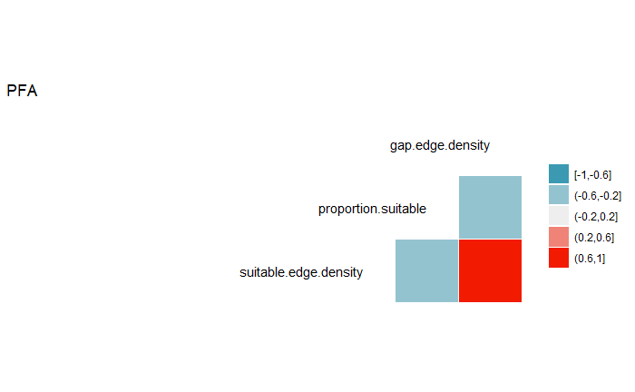

```r
# For the smallest scale, PFA.
sig.pfa <- occupancy.models %>% map(tidy) %>%
  bind_rows(.id='size') %>%
  filter(p.value <= 0.05) %>%
  filter(term != '(Intercept)') %>%
  filter(size == 'PFA') %>%
  select(term, p.value) %>%
  pivot_wider(names_from=term, values_from=p.value)

sig.pfa <-intersect(names(data), names(sig.pfa))

data %>% select(all_of(sig.pfa)) %>%
  ggcorr(method=c('pairwise', 'pearson'), nbreaks=5, hjust=1, layout.exp=5) +
  labs(title='PFA')
```

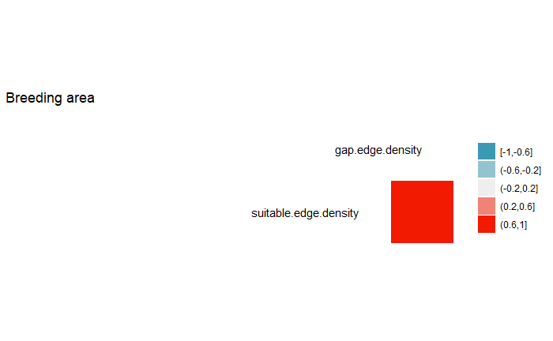

```r
# For the breeding area.
sig.breeding <- occupancy.models %>% map(tidy) %>%
  bind_rows(.id='size') %>%
  filter(p.value <= 0.05) %>%
  filter(term != '(Intercept)') %>%
  filter(size == 'breeding area') %>%
  select(term, p.value) %>%
  pivot_wider(names_from=term, values_from=p.value)

sig.breeding <-intersect(names(data), names(sig.breeding))

data %>% select(all_of(sig.breeding)) %>%
  ggcorr(method=c('pairwise', 'pearson'), nbreaks=5, hjust=1, layout.exp=5) +
  labs(title='Breeding area')
```

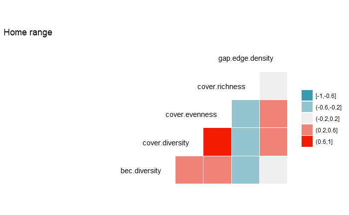

```r
# For the home range.
sig.hr <- occupancy.models %>% map(tidy) %>%
  bind_rows(.id='size') %>%
  filter(p.value <= 0.05) %>%
  filter(term != '(Intercept)') %>%
  filter(size == 'home range') %>%
  select(term, p.value) %>%
  pivot_wider(names_from=term, values_from=p.value)

sig.hr <-intersect(names(data), names(sig.hr))

data %>% select(all_of(sig.hr)) %>%
  ggcorr(method=c('pairwise', 'pearson'), nbreaks=5, hjust=1, layout.exp=5) +
  labs(title='Home range')
```

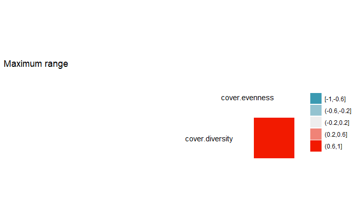

```r
# For the max range.
sig.max <- occupancy.models %>% map(tidy) %>%
  bind_rows(.id='size') %>%
  filter(p.value <= 0.05) %>%
  filter(term != '(Intercept)') %>%
  filter(size == 'maximum range') %>%
  select(term, p.value) %>%
  pivot_wider(names_from=term, values_from=p.value)

sig.max <-intersect(names(data), names(sig.max))

data %>% select(all_of(sig.max)) %>%
  ggcorr(method=c('pairwise', 'pearson'), nbreaks=5, hjust=1, layout.exp=5) +
  labs(title='Maximum range')
```

Yes, unsurprisingly, many are quite correlated.

To be very thorough, how about a full set of correlation matrices?

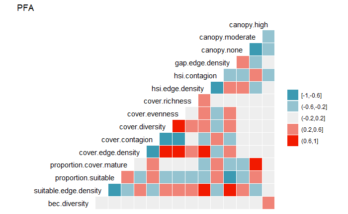

```r
data %>% filter(size == 'PFA') %>%
  select(12:26) %>%
  ggcorr(method=c('pairwise', 'pearson'), nbreaks=5, hjust=1, layout.exp=5) +
  labs(title='PFA')
```

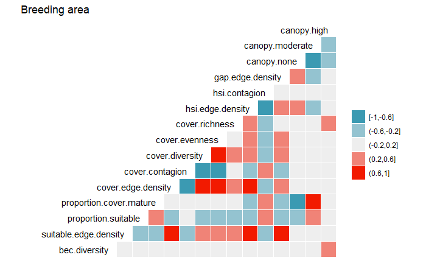

```r
data %>% filter(size == 'breeding area') %>%
  select(12:26) %>%
  ggcorr(method=c('pairwise', 'pearson'), nbreaks=5, hjust=1, layout.exp=5) +
  labs(title='Breeding area')
```

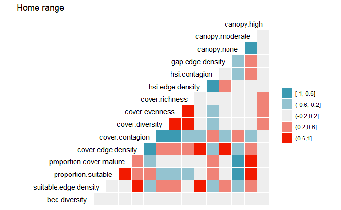

```r
data %>% filter(size == 'home range') %>%
  select(12:26) %>%
  ggcorr(method=c('pairwise', 'pearson'), nbreaks=5, hjust=1, layout.exp=5) +
  labs(title='Home range')
```

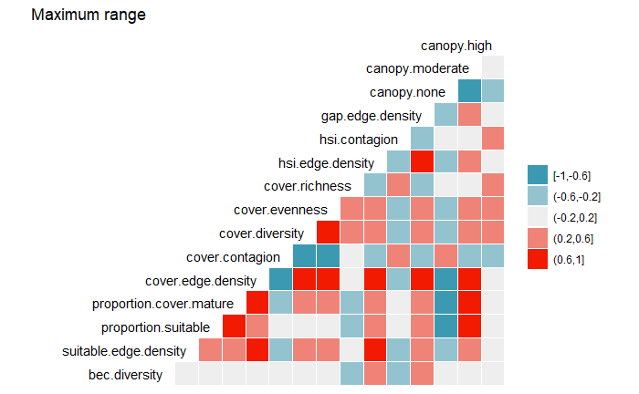

```r
data %>% filter(size == 'maximum range') %>%
  select(12:26) %>%
  ggcorr(method=c('pairwise', 'pearson'), nbreaks=5, hjust=1, layout.exp=5) +
  labs(title='Maximum range')
```

We can plot some of them, to see if any are pretty.

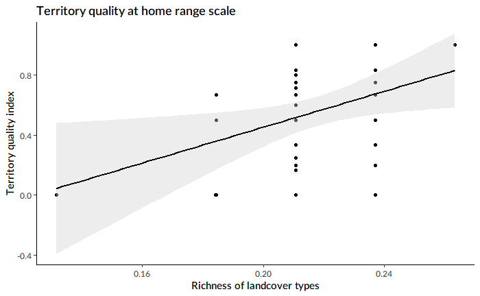

```r
data %>% filter(size == 'home range') %>%
  ggplot(aes(x=cover.richness, y=proportion.occupied, weight=years.surveyed)) +
  geom_point() +
  geom_smooth(formula='y ~ x', method='lm', se=TRUE, col='black', fill='lightgrey') +
  labs(title='Territory quality at home range scale') +
  ylab('Territory quality index') +
  xlab('Richness of landcover types') +
  theme_classic() +
  theme(text=element_text(family="Lato Semibold"))
```

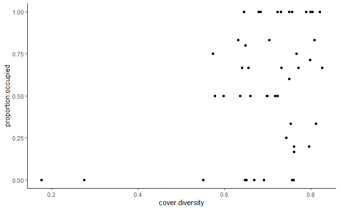

```r
data %>% filter(size == 'home range') %>%
  ggplot(aes(x=cover.diversity, y=proportion.occupied)) +
  geom_point() +
  theme_classic()
```

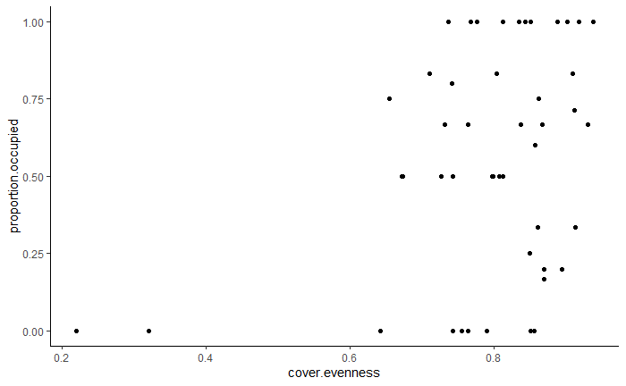

```r
data %>% filter(size == 'home range') %>%
  ggplot(aes(x=cover.evenness, y=proportion.occupied)) +
  geom_point() +
  theme_classic()
```

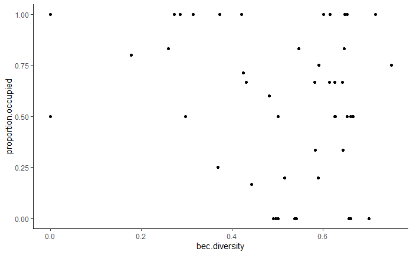

```r
data %>% filter(size == 'home range') %>%
  ggplot(aes(x=bec.diversity, y=proportion.occupied)) +
  geom_point() +
  theme_classic()
```

But none of them are pretty :(